# Module 91

#### Hemi-module gene counts:

620 probesets in hemi-module A.  
35 probesets in hemi-module B.  
Note: While the mapping of probesets to genes is usually one-to-one, some genes are targeted by multiple probesets, some probesets target multiple genes, and some probesets do not target any genes (i.e., the region of the genome they match is no longer considered genic).

#### Contrast SVE:

Signed variance explained (SVE) provides an indication of how similar a set of fold changes are to a gene module’s weight vector. An SVE value of 0.3, for example, indicates that 30% of the variance explained by the entire module set is accounted for by the module in question. Shown here are the SVE values for this module across a compendium of fold changes (contrasts). Extreme SVE values (e.g., > 0.05) indicate that those contrasts specifically induce (orange dots) or specifically repress (blue dots) this module. Examining the experimental conditions being compared in such contrasts (see tables below the figure) may provide insight into the gene module’s function.

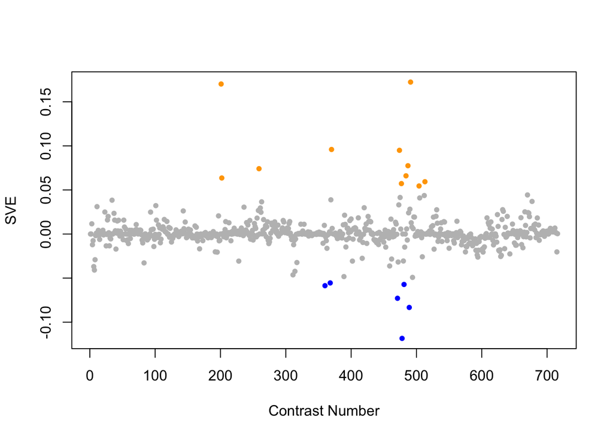

Positive SVE Contrasts:

|  | Contrast.Num | SVE | GEO.GSE | Cond.1 | Cond.2 | Mutation |
| --- | --- | --- | --- | --- | --- | --- |
| GSE23528B.s1t5.vs.s1t1 | 491 | 0.17 | GSE23528 | Adult at T42 in CC, time-series experiment 3 | Adult at T26 in CC, time-series experiment 3 |  |
| GSE43959.s3t2.vs.s3t1 | 201 | 0.17 | GSE43959 | N2 gravid adult on Comamonas DA1877 rep 1 | N2 young adult on Comamonas DA1877 rep 1 |  |
| GSE35360B.s2t1.vs.s0t1 | 370 | 0.10 | GSE35360 | HF 3d_2.0_rep1 | HF 3d control_rep1 |  |
| GSE23528A.s1t4.vs.s1t1 | 474 | 0.09 | GSE23528 | Adult at T14 in LD, time-series experiment 3 | Adult at T2 in LD, time-series experiment 3 |  |
| GSE23528A.s0t2.vs.s0t1 | 487 | 0.08 | GSE23528 | Adult at T6, non-entrained control time-series experiment 4 | Adult at T2, non-entrained control time-series experiment 4 |  |
| GSE41366A.s1t3.vs.s0t3 | 259 | 0.07 | GSE41366 | low_DDVP-2h_expose-20h_harvest-rep1 | control-2h_expose-20h_harvest-rep1 |  |
| GSE23528A.s0t4.vs.s0t1 | 484 | 0.07 | GSE23528 | Adult at T14, non-entrained control time-series experiment 4 | Adult at T2, non-entrained control time-series experiment 4 |  |
| GSE43959.s1t2.vs.s1t1 | 202 | 0.06 | GSE43959 | N2 gravid adult on E. coli OP50 rep 1 | N2 young adult on E. coli OP50 rep 1 |  |
| GSE2180.s4t1.vs.s2t1 | 513 | 0.06 | GSE2180 | pp0-1 | ms0-1 |  |
| GSE23528A.s1t2.vs.s1t1 | 477 | 0.06 | GSE23528 | Adult at T6 in LD, time-series experiment 3 | Adult at T2 in LD, time-series experiment 3 |  |
| GSE22660.s0t2.vs.s0t1 | 504 | 0.05 | GSE22660 | 1ug/ml DMSO control, biological rep 1 | 100ng/ml DMSO control, biological rep 1 |  |

Negative SVE Contrasts:

|  | Contrast.Num | SVE | GEO.GSE | Cond.1 | Cond.2 | Mutation |
| --- | --- | --- | --- | --- | --- | --- |
| GSE23528A.s2t3.vs.s2t1 | 478 | -0.12 | GSE23528 | Adult at T10 in WC, time-series experiment 1 | Adult at T2 in WC, time-series experiment 1 |  |
| GSE23528B.s1t3.vs.s1t1 | 489 | -0.08 | GSE23528 | Adult at T34 in CC, time-series experiment 3 | Adult at T26 in CC, time-series experiment 3 |  |
| GSE23528A.s1t2.vs.s0t2 | 471 | -0.07 | GSE23528 | Adult at T6 in LD, time-series experiment 3 | Adult at T6, non-entrained control time-series experiment 4 |  |
| GSE37432.s1t1.vs.s0t1 | 360 | -0.06 | GSE37432 | piwi n4357 n4358 rep1 | N2 rep1 | prg-1;prg-2 |
| GSE23528A.s2t6.vs.s2t1 | 481 | -0.06 | GSE23528 | Adult at T22 in WC, time-series experiment 1 | Adult at T2 in WC, time-series experiment 1 |  |
| GSE35360A.s2t1.vs.s0t1 | 368 | -0.06 | GSE35360 | HF 11d_2.0_rep1 | HF 11d control_rep1 |  |

$~$

#### Contrast SVE, Up-Regulated Genes Only:

Calculating SVE for up-regulated and down-regulated genes separately may be more informative in many cases than projecting the up- and down- gene sets together. This is due to the fact that the weight distribution of many modules is highly skewed, indicating that only one of the hemi-modules may be biologically meaningful (i.e., a set of genes are strongly correlated by only a few genes (or none) are strongly anti-correlated to that set.)

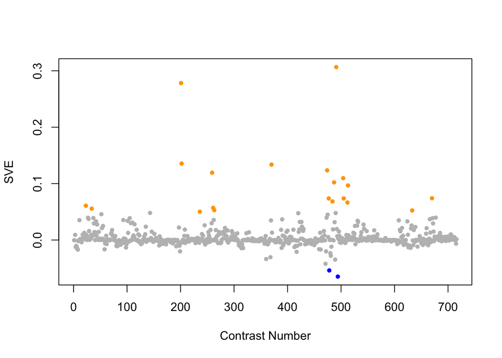

Positive SVE Contrasts:

|  | Contrast.Num | SVE | GEO.GSE | Cond.1 | Cond.2 | Mutation |
| --- | --- | --- | --- | --- | --- | --- |
| GSE23528B.s1t5.vs.s1t1 | 491 | 0.31 | GSE23528 | Adult at T42 in CC, time-series experiment 3 | Adult at T26 in CC, time-series experiment 3 |  |
| GSE43959.s3t2.vs.s3t1 | 201 | 0.28 | GSE43959 | N2 gravid adult on Comamonas DA1877 rep 1 | N2 young adult on Comamonas DA1877 rep 1 |  |
| GSE43959.s1t2.vs.s1t1 | 202 | 0.14 | GSE43959 | N2 gravid adult on E. coli OP50 rep 1 | N2 young adult on E. coli OP50 rep 1 |  |
| GSE35360B.s2t1.vs.s0t1 | 370 | 0.13 | GSE35360 | HF 3d_2.0_rep1 | HF 3d control_rep1 |  |
| GSE23528A.s1t4.vs.s1t1 | 474 | 0.12 | GSE23528 | Adult at T14 in LD, time-series experiment 3 | Adult at T2 in LD, time-series experiment 3 |  |
| GSE41366A.s1t3.vs.s0t3 | 259 | 0.12 | GSE41366 | low_DDVP-2h_expose-20h_harvest-rep1 | control-2h_expose-20h_harvest-rep1 |  |
| GSE22660.s0t2.vs.s0t1 | 504 | 0.11 | GSE22660 | 1ug/ml DMSO control, biological rep 1 | 100ng/ml DMSO control, biological rep 1 |  |
| GSE23528A.s0t2.vs.s0t1 | 487 | 0.10 | GSE23528 | Adult at T6, non-entrained control time-series experiment 4 | Adult at T2, non-entrained control time-series experiment 4 |  |
| GSE2180.s4t1.vs.s2t1 | 513 | 0.10 | GSE2180 | pp0-1 | ms0-1 |  |
| GSE15016.s2t1.vs.s0t1 | 670 | 0.07 | GSE15016 | young adult_24hr NP exposure_rep1 | young adult_not exposured_rep1 |  |
| GSE22660.s1t2.vs.s1t1 | 505 | 0.07 | GSE22660 | 1ug/ml ivermectin exposure, biological rep 1 | 100ng/ml ivermectin exposure, biological rep 1 |  |
| GSE23528A.s1t2.vs.s1t1 | 477 | 0.07 | GSE23528 | Adult at T6 in LD, time-series experiment 3 | Adult at T2 in LD, time-series experiment 3 |  |
| GSE23528A.s0t4.vs.s0t1 | 484 | 0.07 | GSE23528 | Adult at T14, non-entrained control time-series experiment 4 | Adult at T2, non-entrained control time-series experiment 4 |  |
| GSE2180.s3t1.vs.s2t1 | 512 | 0.07 | GSE2180 | p0-3 | ms0-1 |  |
| GSE9665.s2t2.vs.s0t2 | 23 | 0.06 | GSE9665 | mex-3 elt-3 186 A | mex-3 186 A | elt-3 |
| GSE41366A.s1t4.vs.s0t4 | 261 | 0.06 | GSE41366 | low_DDVP-2h_expose-26h_harvest-rep1 | control-2h_expose-26h_harvest-rep1 |  |
| GSE9665.s2t3.vs.s0t3 | 34 | 0.06 | GSE9665 | mex-3 elt-3 230 A | mex-3 230 A | elt-3 |
| GSE41366A.s1t1.vs.s0t1 | 263 | 0.05 | GSE41366 | low_DDVP-2h_expose-8h_harvest-rep1 | control-2h_expose-8h_harvest-rep1 |  |
| GSE19310B.s1t3.vs.s1t1 | 633 | 0.05 | GSE19310 | N2 at 200 for 6 hours, rep1 | N2 at 200 for 15min, rep1 |  |
| GSE42592B.s2t3.vs.s2t2 | 236 | 0.05 | GSE42592 | cadmium_mid_expose-8h_rep1 | cadmium_mid_expose-4h_rep1 |  |

Negative SVE Contrasts:

|  | Contrast.Num | SVE | GEO.GSE | Cond.1 | Cond.2 | Mutation |
| --- | --- | --- | --- | --- | --- | --- |
| GSE23528C.s1t3.vs.s1t1 | 494 | -0.06 | GSE23528 | Adult at T34 in DD, time-series experiment 2 | Adult at T26 in DD, time-series experiment 2 |  |
| GSE23528A.s2t3.vs.s2t1 | 478 | -0.05 | GSE23528 | Adult at T10 in WC, time-series experiment 1 | Adult at T2 in WC, time-series experiment 1 |  |
| GSE23528A.s1t2.vs.s0t2 | 471 | -0.04 | GSE23528 | Adult at T6 in LD, time-series experiment 3 | Adult at T6, non-entrained control time-series experiment 4 |  |
| GSE23528B.s1t3.vs.s1t1 | 489 | -0.03 | GSE23528 | Adult at T34 in CC, time-series experiment 3 | Adult at T26 in CC, time-series experiment 3 |  |
| GSE37432.s1t1.vs.s0t1 | 360 | -0.03 | GSE37432 | piwi n4357 n4358 rep1 | N2 rep1 | prg-1;prg-2 |

$~$

#### Contrast SVE, Down-Regulated Genes Only:

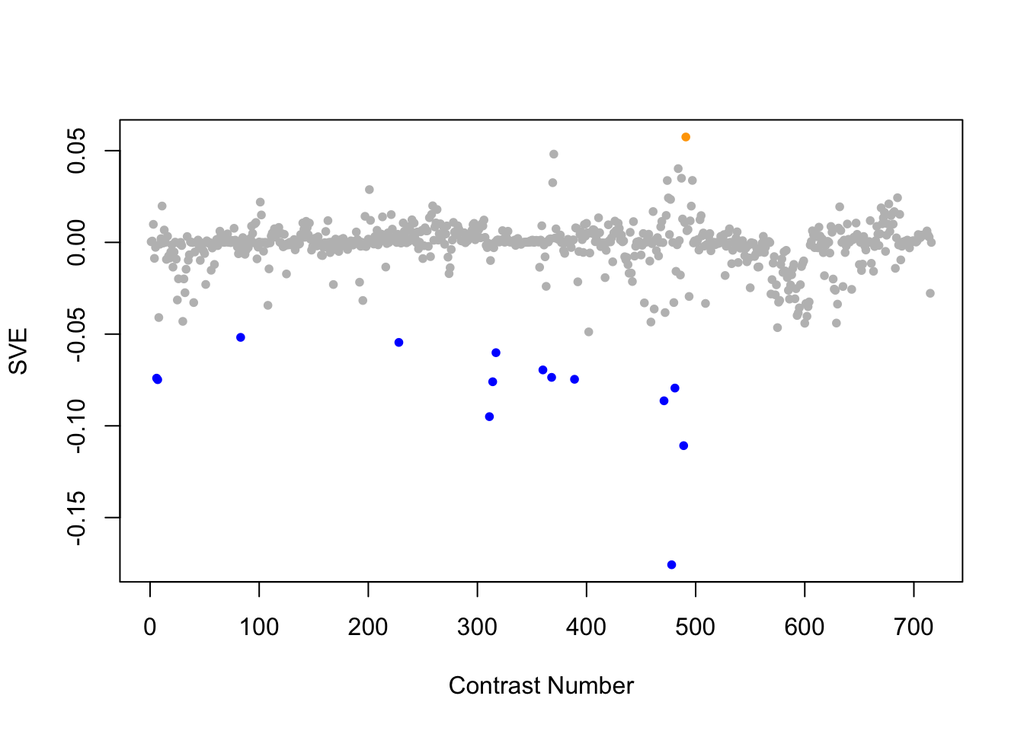

Positive SVE Contrasts:

|  | Contrast.Num | SVE | GEO.GSE | Cond.1 | Cond.2 | Mutation |
| --- | --- | --- | --- | --- | --- | --- |
| GSE23528B.s1t5.vs.s1t1 | 491 | 0.06 | GSE23528 | Adult at T42 in CC, time-series experiment 3 | Adult at T26 in CC, time-series experiment 3 |  |
| GSE35360B.s2t1.vs.s0t1 | 370 | 0.05 | GSE35360 | HF 3d_2.0_rep1 | HF 3d control_rep1 |  |
| GSE23528A.s0t4.vs.s0t1 | 484 | 0.04 | GSE23528 | Adult at T14, non-entrained control time-series experiment 4 | Adult at T2, non-entrained control time-series experiment 4 |  |
| GSE23528A.s0t2.vs.s0t1 | 487 | 0.03 | GSE23528 | Adult at T6, non-entrained control time-series experiment 4 | Adult at T2, non-entrained control time-series experiment 4 |  |
| GSE23528C.s1t6.vs.s1t1 | 497 | 0.03 | GSE23528 | Adult at T46 in DD, time-series experiment 2 | Adult at T26 in DD, time-series experiment 2 |  |

Negative SVE Contrasts:

|  | Contrast.Num | SVE | GEO.GSE | Cond.1 | Cond.2 | Mutation |
| --- | --- | --- | --- | --- | --- | --- |
| GSE23528A.s2t3.vs.s2t1 | 478 | -0.18 | GSE23528 | Adult at T10 in WC, time-series experiment 1 | Adult at T2 in WC, time-series experiment 1 |  |
| GSE23528B.s1t3.vs.s1t1 | 489 | -0.11 | GSE23528 | Adult at T34 in CC, time-series experiment 3 | Adult at T26 in CC, time-series experiment 3 |  |
| GSE41056.s2t2.vs.s0t2 | 311 | -0.09 | GSE41056 | RDE_1_inf_1 | N2_inf_1 | rde-1 |
| GSE23528A.s1t2.vs.s0t2 | 471 | -0.09 | GSE23528 | Adult at T6 in LD, time-series experiment 3 | Adult at T6, non-entrained control time-series experiment 4 |  |
| GSE23528A.s2t6.vs.s2t1 | 481 | -0.08 | GSE23528 | Adult at T22 in WC, time-series experiment 1 | Adult at T2 in WC, time-series experiment 1 |  |
| GSE41056.s2t2.vs.s2t1 | 314 | -0.08 | GSE41056 | RDE_1_inf_1 | RDE_1_1 |  |
| GSE9897B.s4t1.vs.s0t1 | 7 | -0.07 | GSE9897 | Complex I RNAi Mutant 4 | Wildtype (control for RNAi) | Y56A3A.19 |
| GSE32942.s2t1.vs.s1t1 | 389 | -0.07 | GSE32942 | WS5041 (mir 58(n4640); alg 1(tm492); opIs205). Replicate 1 | WS4303 (alg 1(tm492); opIs205). Replicate 1 | mir-58 |
| GSE9897B.s3t1.vs.s0t1 | 6 | -0.07 | GSE9897 | Complex I RNAi Mutant 3 | Wildtype (control for RNAi) | C34B2.8 |
| GSE35360A.s2t1.vs.s0t1 | 368 | -0.07 | GSE35360 | HF 11d_2.0_rep1 | HF 11d control_rep1 |  |
| GSE37432.s1t1.vs.s0t1 | 360 | -0.07 | GSE37432 | piwi n4357 n4358 rep1 | N2 rep1 | prg-1;prg-2 |
| GSE39145.s1t1.vs.s0t1 | 317 | -0.06 | GSE39145 | ercc-1_I | wild-type_N2_I | ercc-1 |
| GSE42592B.s2t2.vs.s0t2 | 228 | -0.05 | GSE42592 | cadmium_mid_expose-4h_rep1 | cadmium_control_expose-4h_rep1 |  |
| GSE6563.s1t1.vs.s0t1 | 83 | -0.05 | GSE6563 | daf19(m86)_daf12(sa204) replicate 1 | daf19(WT)_daf12(sa204) replicate 1 | daf-19 |

$~$

$~$

#### GO Term Enrichment:

This analysis tests each hemi-module for enrichment of specific GO terms. Only gene-level annotations (e.g., as would be found on the gene’s page in Wormbase) are tested - the hierarchical structure of the GO ontology is not taken into account.

*Note: At least the top two most enriched terms from each GO domain (BP/MF/CC) are shown, even when not statistically significant.*

##### Enriched GO terms: Hemi-module A

| ID | GO.Term | GO Domain | Raw p-value | Adj p-value |
| --- | --- | --- | --- | --- |
| [GO_0008033](http://amigo.geneontology.org/amigo/term/GO:0008033) | tRNA processing | BP | 5.43e-07 | 1.98e-03 |
| [GO_0006506](http://amigo.geneontology.org/amigo/term/GO:0006506) | GPI anchor biosynthetic process | BP | 6.12e-06 | 6.04e-03 |
| [GO_0032259](http://amigo.geneontology.org/amigo/term/GO:0032259) | methylation | BP | 6.40e-06 | 6.04e-03 |
| [GO_0034427](http://amigo.geneontology.org/amigo/term/GO:0034427) | nuclear-transcribed mRNA catabolic process, exonucleolytic, 3’-5’ | BP | 8.49e-06 | 6.04e-03 |
| [GO_0034475](http://amigo.geneontology.org/amigo/term/GO:0034475) | U4 snRNA 3’-end processing | BP | 8.49e-06 | 6.04e-03 |
| [GO_0007186](http://amigo.geneontology.org/amigo/term/GO:0007186) | G protein-coupled receptor signaling pathway | BP | 9.95e-06 | 6.04e-03 |
| [GO_0016192](http://amigo.geneontology.org/amigo/term/GO:0016192) | vesicle-mediated transport | BP | 5.42e-05 | 2.82e-02 |
| [GO_0008643](http://amigo.geneontology.org/amigo/term/GO:0008643) | carbohydrate transport | BP | 7.76e-05 | 3.53e-02 |
| [GO_0002143](http://amigo.geneontology.org/amigo/term/GO:0002143) | tRNA wobble position uridine thiolation | BP | 1.88e-04 | 5.33e-02 |
| [GO_0016075](http://amigo.geneontology.org/amigo/term/GO:0016075) | rRNA catabolic process | BP | 1.88e-04 | 5.33e-02 |
| [GO_0071028](http://amigo.geneontology.org/amigo/term/GO:0071028) | nuclear mRNA surveillance | BP | 1.88e-04 | 5.33e-02 |
| [GO_1990569](http://amigo.geneontology.org/amigo/term/GO:1990569) | UDP-N-acetylglucosamine transmembrane transport | BP | 1.88e-04 | 5.33e-02 |
| [GO_0048278](http://amigo.geneontology.org/amigo/term/GO:0048278) | vesicle docking | BP | 1.90e-04 | 5.33e-02 |
| [GO_0090502](http://amigo.geneontology.org/amigo/term/GO:0090502) | RNA phosphodiester bond hydrolysis, endonucleolytic | BP | 2.73e-04 | 7.11e-02 |
| [GO_0090305](http://amigo.geneontology.org/amigo/term/GO:0090305) | nucleic acid phosphodiester bond hydrolysis | BP | 3.39e-04 | 8.24e-02 |
| [GO_0017183](http://amigo.geneontology.org/amigo/term/GO:0017183) | peptidyl-diphthamide biosynthetic process from peptidyl-histidine | BP | 4.57e-04 | 8.76e-02 |
| [GO_0043928](http://amigo.geneontology.org/amigo/term/GO:0043928) | exonucleolytic nuclear-transcribed mRNA catabolic process involved in deadenylation-dependent decay | BP | 4.57e-04 | 8.76e-02 |
| [GO_0071035](http://amigo.geneontology.org/amigo/term/GO:0071035) | nuclear polyadenylation-dependent rRNA catabolic process | BP | 4.57e-04 | 8.76e-02 |
| [GO_0071038](http://amigo.geneontology.org/amigo/term/GO:0071038) | nuclear polyadenylation-dependent tRNA catabolic process | BP | 4.57e-04 | 8.76e-02 |
| [GO_0008168](http://amigo.geneontology.org/amigo/term/GO:0008168) | methyltransferase activity | MF | 6.79e-08 | 1.39e-04 |
| [GO_0017176](http://amigo.geneontology.org/amigo/term/GO:0017176) | phosphatidylinositol N-acetylglucosaminyltransferase activity | MF | 4.83e-05 | 4.93e-02 |
| [GO_0008138](http://amigo.geneontology.org/amigo/term/GO:0008138) | protein tyrosine/serine/threonine phosphatase activity | MF | 1.40e-04 | 9.54e-02 |
| [GO_0005462](http://amigo.geneontology.org/amigo/term/GO:0005462) | UDP-N-acetylglucosamine transmembrane transporter activity | MF | 1.88e-04 | 9.59e-02 |
| [GO_0016740](http://amigo.geneontology.org/amigo/term/GO:0016740) | transferase activity | MF | 2.38e-04 | 9.72e-02 |
| [GO_0005794](http://amigo.geneontology.org/amigo/term/GO:0005794) | Golgi apparatus | CC | 7.61e-08 | 3.37e-05 |
| [GO_0005783](http://amigo.geneontology.org/amigo/term/GO:0005783) | endoplasmic reticulum | CC | 7.91e-08 | 3.37e-05 |
| [GO_0005739](http://amigo.geneontology.org/amigo/term/GO:0005739) | mitochondrion | CC | 1.09e-07 | 3.37e-05 |
| [GO_0000177](http://amigo.geneontology.org/amigo/term/GO:0000177) | cytoplasmic exosome (RNase complex) | CC | 2.47e-05 | 5.74e-03 |
| [GO_0030176](http://amigo.geneontology.org/amigo/term/GO:0030176) | integral component of endoplasmic reticulum membrane | CC | 3.50e-05 | 6.23e-03 |
| [GO_0000139](http://amigo.geneontology.org/amigo/term/GO:0000139) | Golgi membrane | CC | 4.03e-05 | 6.23e-03 |
| [GO_0000506](http://amigo.geneontology.org/amigo/term/GO:0000506) | glycosylphosphatidylinositol-N-acetylglucosaminyltransferase (GPI-GnT) complex | CC | 4.83e-05 | 6.40e-03 |
| [GO_0016021](http://amigo.geneontology.org/amigo/term/GO:0016021) | integral component of membrane | CC | 9.65e-05 | 1.12e-02 |
| [GO_0000176](http://amigo.geneontology.org/amigo/term/GO:0000176) | nuclear exosome (RNase complex) | CC | 1.90e-04 | 1.96e-02 |
| [GO_0005762](http://amigo.geneontology.org/amigo/term/GO:0005762) | mitochondrial large ribosomal subunit | CC | 3.51e-04 | 3.26e-02 |
| [GO_0005887](http://amigo.geneontology.org/amigo/term/GO:0005887) | integral component of plasma membrane | CC | 4.26e-04 | 3.39e-02 |
| [GO_0016020](http://amigo.geneontology.org/amigo/term/GO:0016020) | membrane | CC | 4.70e-04 | 3.39e-02 |
| [GO_0005730](http://amigo.geneontology.org/amigo/term/GO:0005730) | nucleolus | CC | 4.74e-04 | 3.39e-02 |
| [GO_0030134](http://amigo.geneontology.org/amigo/term/GO:0030134) | COPII-coated ER to Golgi transport vesicle | CC | 6.85e-04 | 4.54e-02 |
| [GO_0005829](http://amigo.geneontology.org/amigo/term/GO:0005829) | cytosol | CC | 1.45e-03 | 8.73e-02 |
| [GO_0030173](http://amigo.geneontology.org/amigo/term/GO:0030173) | integral component of Golgi membrane | CC | 1.50e-03 | 8.73e-02 |

##### Enriched GO terms: Hemi-module B

| ID | GO.Term | GO Domain | Raw p-value | Adj p-value |
| --- | --- | --- | --- | --- |
| [GO_0097484](http://amigo.geneontology.org/amigo/term/GO:0097484) | dendrite extension | BP | 1.83e-03 | 1.00e+00 |
| [GO_2000574](http://amigo.geneontology.org/amigo/term/GO:2000574) | regulation of microtubule motor activity | BP | 1.83e-03 | 1.00e+00 |
| [GO_0001099](http://amigo.geneontology.org/amigo/term/GO:0001099) | basal RNA polymerase II transcription machinery binding | MF | 1.83e-03 | 1.00e+00 |
| [GO_0003723](http://amigo.geneontology.org/amigo/term/GO:0003723) | RNA binding | MF | 5.38e-03 | 1.00e+00 |
| [GO_0005730](http://amigo.geneontology.org/amigo/term/GO:0005730) | nucleolus | CC | 1.90e-03 | 1.00e+00 |
| [GO_0033565](http://amigo.geneontology.org/amigo/term/GO:0033565) | ESCRT-0 complex | CC | 3.65e-03 | 1.00e+00 |

$~$

$~$

#### Tissue Enrichment:

This analysis tests each hemi-module for enrichment of genes associated with anatomy terms. Negative enrichment scores indicate fewer hemi-module genes than expected by random chance were associated with the anatomy term in question.

##### Enriched tissues: Hemi-module A

No significant annotations.

##### Enriched tissues: Hemi-module B

No significant annotations.

$~$

$~$

#### HOMER promoter motif enrichment:

This analysis tests each hemi-module for enrichment of 108 known *C. elegans* transcription factor binding site motifs (see [108 CE motifs](https://katiepod.github.io//all.worm.motifs.html)) using the HOMER (Hypergeometric Optimization of Motif EnRichment) software (see [PMID:20513432](https://pubmed.ncbi.nlm.nih.gov/20513432)). HOMER was run using default parameters on sequences 1 kb upstream of the transcription start site.

##### Motif enrichment: Hemi-module A

Total target sequences = 541  
Total background sequences = 38143  
* - possible false positive

Rank

Motif

P-value

log P-pvalue

% of Targets

% of Background

STD(Bg STD)

Best Match/Details

Motif File

1

[figure not shown]

1e-16

-3.694e+01

7.76%

1.54%

240.1bp (329.1bp)

PHA-4(Forkhead)/cElegans-Embryos-PHA4-ChIP-Seq(modEncode)/Homer(0.743)  
[More Information](https://katiepod.github.io/HomerResults/m91_a_hemi_genes.txt.out.1kb/homerResults/motif1.info.html) | [Similar Motifs Found](https://katiepod.github.io/HomerResults/m91_a_hemi_genes.txt.out.1kb/homerResults/motif1.similar.html)

[motif file (matrix)](https://katiepod.github.io/HomerResults/m91_a_hemi_genes.txt.out.1kb/homerResults/motif1.motif)

2

[figure not shown]

1e-15

-3.645e+01

49.35%

32.16%

289.9bp (318.3bp)

MF0005.1_Forkhead_class/Jaspar(0.710)  
[More Information](https://katiepod.github.io/HomerResults/m91_a_hemi_genes.txt.out.1kb/homerResults/motif2.info.html) | [Similar Motifs Found](https://katiepod.github.io/HomerResults/m91_a_hemi_genes.txt.out.1kb/homerResults/motif2.similar.html)

[motif file (matrix)](https://katiepod.github.io/HomerResults/m91_a_hemi_genes.txt.out.1kb/homerResults/motif2.motif)

3

[figure not shown]

1e-13

-3.074e+01

22.55%

11.12%

282.0bp (320.1bp)

daf-12/MA0538.1/Jaspar(0.576)  
[More Information](https://katiepod.github.io/HomerResults/m91_a_hemi_genes.txt.out.1kb/homerResults/motif3.info.html) | [Similar Motifs Found](https://katiepod.github.io/HomerResults/m91_a_hemi_genes.txt.out.1kb/homerResults/motif3.similar.html)

[motif file (matrix)](https://katiepod.github.io/HomerResults/m91_a_hemi_genes.txt.out.1kb/homerResults/motif3.motif)

4

[figure not shown]

1e-12

-2.985e+01

50.28%

34.68%

282.3bp (331.4bp)

eor-1/MA0543.1/Jaspar(0.562)  
[More Information](https://katiepod.github.io/HomerResults/m91_a_hemi_genes.txt.out.1kb/homerResults/motif4.info.html) | [Similar Motifs Found](https://katiepod.github.io/HomerResults/m91_a_hemi_genes.txt.out.1kb/homerResults/motif4.similar.html)

[motif file (matrix)](https://katiepod.github.io/HomerResults/m91_a_hemi_genes.txt.out.1kb/homerResults/motif4.motif)

5

[figure not shown]

1e-12

-2.970e+01

4.81%

0.71%

280.0bp (287.4bp)

cebp-1/MA1444.1/Jaspar(0.637)  
[More Information](https://katiepod.github.io/HomerResults/m91_a_hemi_genes.txt.out.1kb/homerResults/motif5.info.html) | [Similar Motifs Found](https://katiepod.github.io/HomerResults/m91_a_hemi_genes.txt.out.1kb/homerResults/motif5.similar.html)

[motif file (matrix)](https://katiepod.github.io/HomerResults/m91_a_hemi_genes.txt.out.1kb/homerResults/motif5.motif)

6

[figure not shown]

1e-12

-2.968e+01

10.35%

3.26%

306.4bp (311.7bp)

MF0010.1_Homeobox_class/Jaspar(0.737)  
[More Information](https://katiepod.github.io/HomerResults/m91_a_hemi_genes.txt.out.1kb/homerResults/motif6.info.html) | [Similar Motifs Found](https://katiepod.github.io/HomerResults/m91_a_hemi_genes.txt.out.1kb/homerResults/motif6.similar.html)

[motif file (matrix)](https://katiepod.github.io/HomerResults/m91_a_hemi_genes.txt.out.1kb/homerResults/motif6.motif)

7

[figure not shown]

1e-12

-2.907e+01

2.03%

0.05%

245.3bp (326.2bp)

POL009.1_DCE_S_II/Jaspar(0.588)  
[More Information](https://katiepod.github.io/HomerResults/m91_a_hemi_genes.txt.out.1kb/homerResults/motif7.info.html) | [Similar Motifs Found](https://katiepod.github.io/HomerResults/m91_a_hemi_genes.txt.out.1kb/homerResults/motif7.similar.html)

[motif file (matrix)](https://katiepod.github.io/HomerResults/m91_a_hemi_genes.txt.out.1kb/homerResults/motif7.motif)

8

[figure not shown]

1e-12

-2.838e+01

4.25%

0.56%

239.9bp (319.3bp)

MF0002.1_bZIP_CREB/G-box-like_subclass/Jaspar(0.606)  
[More Information](https://katiepod.github.io/HomerResults/m91_a_hemi_genes.txt.out.1kb/homerResults/motif8.info.html) | [Similar Motifs Found](https://katiepod.github.io/HomerResults/m91_a_hemi_genes.txt.out.1kb/homerResults/motif8.similar.html)

[motif file (matrix)](https://katiepod.github.io/HomerResults/m91_a_hemi_genes.txt.out.1kb/homerResults/motif8.motif)

9

[figure not shown]

1e-12

-2.826e+01

2.03%

0.06%

309.8bp (331.6bp)

pqm-1/MA1703.1/Jaspar(0.657)  
[More Information](https://katiepod.github.io/HomerResults/m91_a_hemi_genes.txt.out.1kb/homerResults/motif9.info.html) | [Similar Motifs Found](https://katiepod.github.io/HomerResults/m91_a_hemi_genes.txt.out.1kb/homerResults/motif9.similar.html)

[motif file (matrix)](https://katiepod.github.io/HomerResults/m91_a_hemi_genes.txt.out.1kb/homerResults/motif9.motif)

10 *

[figure not shown]

1e-11

-2.684e+01

7.76%

2.12%

263.8bp (317.1bp)

SD0003.1_at_AC_acceptor/Jaspar(0.730)  
[More Information](https://katiepod.github.io/HomerResults/m91_a_hemi_genes.txt.out.1kb/homerResults/motif10.info.html) | [Similar Motifs Found](https://katiepod.github.io/HomerResults/m91_a_hemi_genes.txt.out.1kb/homerResults/motif10.similar.html)

[motif file (matrix)](https://katiepod.github.io/HomerResults/m91_a_hemi_genes.txt.out.1kb/homerResults/motif10.motif)

11 *

[figure not shown]

1e-11

-2.605e+01

1.66%

0.03%

308.0bp (330.3bp)

ceh-22/MA0264.1/Jaspar(0.458)  
[More Information](https://katiepod.github.io/HomerResults/m91_a_hemi_genes.txt.out.1kb/homerResults/motif11.info.html) | [Similar Motifs Found](https://katiepod.github.io/HomerResults/m91_a_hemi_genes.txt.out.1kb/homerResults/motif11.similar.html)

[motif file (matrix)](https://katiepod.github.io/HomerResults/m91_a_hemi_genes.txt.out.1kb/homerResults/motif11.motif)

12 *

[figure not shown]

1e-11

-2.552e+01

2.96%

0.26%

220.2bp (327.3bp)

che-1/MA0260.1/Jaspar(0.501)  
[More Information](https://katiepod.github.io/HomerResults/m91_a_hemi_genes.txt.out.1kb/homerResults/motif12.info.html) | [Similar Motifs Found](https://katiepod.github.io/HomerResults/m91_a_hemi_genes.txt.out.1kb/homerResults/motif12.similar.html)

[motif file (matrix)](https://katiepod.github.io/HomerResults/m91_a_hemi_genes.txt.out.1kb/homerResults/motif12.motif)

13 *

[figure not shown]

1e-10

-2.493e+01

6.10%

1.44%

298.8bp (323.9bp)

blmp-1/MA0537.1/Jaspar(0.596)  
[More Information](https://katiepod.github.io/HomerResults/m91_a_hemi_genes.txt.out.1kb/homerResults/motif13.info.html) | [Similar Motifs Found](https://katiepod.github.io/HomerResults/m91_a_hemi_genes.txt.out.1kb/homerResults/motif13.similar.html)

[motif file (matrix)](https://katiepod.github.io/HomerResults/m91_a_hemi_genes.txt.out.1kb/homerResults/motif13.motif)

14 *

[figure not shown]

1e-10

-2.389e+01

36.60%

23.93%

262.9bp (344.3bp)

POL008.1_DCE_S_I/Jaspar(0.717)  
[More Information](https://katiepod.github.io/HomerResults/m91_a_hemi_genes.txt.out.1kb/homerResults/motif14.info.html) | [Similar Motifs Found](https://katiepod.github.io/HomerResults/m91_a_hemi_genes.txt.out.1kb/homerResults/motif14.similar.html)

[motif file (matrix)](https://katiepod.github.io/HomerResults/m91_a_hemi_genes.txt.out.1kb/homerResults/motif14.motif)

15 *

[figure not shown]

1e-10

-2.346e+01

4.44%

0.80%

298.9bp (331.1bp)

POL008.1_DCE_S_I/Jaspar(0.537)  
[More Information](https://katiepod.github.io/HomerResults/m91_a_hemi_genes.txt.out.1kb/homerResults/motif15.info.html) | [Similar Motifs Found](https://katiepod.github.io/HomerResults/m91_a_hemi_genes.txt.out.1kb/homerResults/motif15.similar.html)

[motif file (matrix)](https://katiepod.github.io/HomerResults/m91_a_hemi_genes.txt.out.1kb/homerResults/motif15.motif)

16 *

[figure not shown]

1e-10

-2.319e+01

6.84%

1.91%

278.4bp (353.2bp)

unc-30/MA1443.1/Jaspar(0.561)  
[More Information](https://katiepod.github.io/HomerResults/m91_a_hemi_genes.txt.out.1kb/homerResults/motif16.info.html) | [Similar Motifs Found](https://katiepod.github.io/HomerResults/m91_a_hemi_genes.txt.out.1kb/homerResults/motif16.similar.html)

[motif file (matrix)](https://katiepod.github.io/HomerResults/m91_a_hemi_genes.txt.out.1kb/homerResults/motif16.motif)

17 *

[figure not shown]

1e-9

-2.279e+01

3.88%

0.62%

286.9bp (345.6bp)

fkh-9/MA1440.1/Jaspar(0.689)  
[More Information](https://katiepod.github.io/HomerResults/m91_a_hemi_genes.txt.out.1kb/homerResults/motif17.info.html) | [Similar Motifs Found](https://katiepod.github.io/HomerResults/m91_a_hemi_genes.txt.out.1kb/homerResults/motif17.similar.html)

[motif file (matrix)](https://katiepod.github.io/HomerResults/m91_a_hemi_genes.txt.out.1kb/homerResults/motif17.motif)

18 *

[figure not shown]

1e-9

-2.196e+01

18.85%

9.89%

244.8bp (336.3bp)

ceh-48/MA0921.1/Jaspar(0.624)  
[More Information](https://katiepod.github.io/HomerResults/m91_a_hemi_genes.txt.out.1kb/homerResults/motif18.info.html) | [Similar Motifs Found](https://katiepod.github.io/HomerResults/m91_a_hemi_genes.txt.out.1kb/homerResults/motif18.similar.html)

[motif file (matrix)](https://katiepod.github.io/HomerResults/m91_a_hemi_genes.txt.out.1kb/homerResults/motif18.motif)

19 *

[figure not shown]

1e-9

-2.154e+01

2.59%

0.25%

297.0bp (325.2bp)

hlh-1/MA0545.1/Jaspar(0.671)  
[More Information](https://katiepod.github.io/HomerResults/m91_a_hemi_genes.txt.out.1kb/homerResults/motif19.info.html) | [Similar Motifs Found](https://katiepod.github.io/HomerResults/m91_a_hemi_genes.txt.out.1kb/homerResults/motif19.similar.html)

[motif file (matrix)](https://katiepod.github.io/HomerResults/m91_a_hemi_genes.txt.out.1kb/homerResults/motif19.motif)

20 *

[figure not shown]

1e-9

-2.118e+01

5.55%

1.40%

232.9bp (317.2bp)

ceh-22/MA0264.1/Jaspar(0.483)  
[More Information](https://katiepod.github.io/HomerResults/m91_a_hemi_genes.txt.out.1kb/homerResults/motif20.info.html) | [Similar Motifs Found](https://katiepod.github.io/HomerResults/m91_a_hemi_genes.txt.out.1kb/homerResults/motif20.similar.html)

[motif file (matrix)](https://katiepod.github.io/HomerResults/m91_a_hemi_genes.txt.out.1kb/homerResults/motif20.motif)

21 *

[figure not shown]

1e-9

-2.111e+01

4.81%

1.06%

321.7bp (337.6bp)

POL009.1_DCE_S_II/Jaspar(0.471)  
[More Information](https://katiepod.github.io/HomerResults/m91_a_hemi_genes.txt.out.1kb/homerResults/motif21.info.html) | [Similar Motifs Found](https://katiepod.github.io/HomerResults/m91_a_hemi_genes.txt.out.1kb/homerResults/motif21.similar.html)

[motif file (matrix)](https://katiepod.github.io/HomerResults/m91_a_hemi_genes.txt.out.1kb/homerResults/motif21.motif)

22 *

[figure not shown]

1e-8

-2.054e+01

2.96%

0.38%

234.6bp (269.0bp)

lin-14/MA0261.1/Jaspar(0.627)  
[More Information](https://katiepod.github.io/HomerResults/m91_a_hemi_genes.txt.out.1kb/homerResults/motif22.info.html) | [Similar Motifs Found](https://katiepod.github.io/HomerResults/m91_a_hemi_genes.txt.out.1kb/homerResults/motif22.similar.html)

[motif file (matrix)](https://katiepod.github.io/HomerResults/m91_a_hemi_genes.txt.out.1kb/homerResults/motif22.motif)

23 *

[figure not shown]

1e-8

-2.026e+01

9.43%

3.63%

311.0bp (321.8bp)

MF0011.1_HMG_class/Jaspar(0.733)  
[More Information](https://katiepod.github.io/HomerResults/m91_a_hemi_genes.txt.out.1kb/homerResults/motif23.info.html) | [Similar Motifs Found](https://katiepod.github.io/HomerResults/m91_a_hemi_genes.txt.out.1kb/homerResults/motif23.similar.html)

[motif file (matrix)](https://katiepod.github.io/HomerResults/m91_a_hemi_genes.txt.out.1kb/homerResults/motif23.motif)

24 *

[figure not shown]

1e-8

-2.016e+01

17.56%

9.26%

281.3bp (332.5bp)

POL004.1_CCAAT-box/Jaspar(0.556)  
[More Information](https://katiepod.github.io/HomerResults/m91_a_hemi_genes.txt.out.1kb/homerResults/motif24.info.html) | [Similar Motifs Found](https://katiepod.github.io/HomerResults/m91_a_hemi_genes.txt.out.1kb/homerResults/motif24.similar.html)

[motif file (matrix)](https://katiepod.github.io/HomerResults/m91_a_hemi_genes.txt.out.1kb/homerResults/motif24.motif)

25 *

[figure not shown]

1e-8

-2.000e+01

6.84%

2.15%

260.4bp (311.4bp)

DPL-1(E2F)/cElegans-Adult-ChIP-Seq(modEncode)/Homer(0.669)  
[More Information](https://katiepod.github.io/HomerResults/m91_a_hemi_genes.txt.out.1kb/homerResults/motif25.info.html) | [Similar Motifs Found](https://katiepod.github.io/HomerResults/m91_a_hemi_genes.txt.out.1kb/homerResults/motif25.similar.html)

[motif file (matrix)](https://katiepod.github.io/HomerResults/m91_a_hemi_genes.txt.out.1kb/homerResults/motif25.motif)

26 *

[figure not shown]

1e-8

-1.914e+01

4.99%

1.27%

240.2bp (339.2bp)

lin-14/MA0261.1/Jaspar(0.644)  
[More Information](https://katiepod.github.io/HomerResults/m91_a_hemi_genes.txt.out.1kb/homerResults/motif26.info.html) | [Similar Motifs Found](https://katiepod.github.io/HomerResults/m91_a_hemi_genes.txt.out.1kb/homerResults/motif26.similar.html)

[motif file (matrix)](https://katiepod.github.io/HomerResults/m91_a_hemi_genes.txt.out.1kb/homerResults/motif26.motif)

27 *

[figure not shown]

1e-8

-1.853e+01

1.85%

0.13%

257.0bp (335.8bp)

POL012.1_TATA-Box/Jaspar(0.592)  
[More Information](https://katiepod.github.io/HomerResults/m91_a_hemi_genes.txt.out.1kb/homerResults/motif27.info.html) | [Similar Motifs Found](https://katiepod.github.io/HomerResults/m91_a_hemi_genes.txt.out.1kb/homerResults/motif27.similar.html)

[motif file (matrix)](https://katiepod.github.io/HomerResults/m91_a_hemi_genes.txt.out.1kb/homerResults/motif27.motif)

28 *

[figure not shown]

1e-7

-1.833e+01

1.48%

0.06%

266.0bp (320.6bp)

MF0001.1_ETS_class/Jaspar(0.593)  
[More Information](https://katiepod.github.io/HomerResults/m91_a_hemi_genes.txt.out.1kb/homerResults/motif28.info.html) | [Similar Motifs Found](https://katiepod.github.io/HomerResults/m91_a_hemi_genes.txt.out.1kb/homerResults/motif28.similar.html)

[motif file (matrix)](https://katiepod.github.io/HomerResults/m91_a_hemi_genes.txt.out.1kb/homerResults/motif28.motif)

29 *

[figure not shown]

1e-7

-1.802e+01

6.10%

1.92%

277.0bp (336.9bp)

POL001.1_MTE/Jaspar(0.544)  
[More Information](https://katiepod.github.io/HomerResults/m91_a_hemi_genes.txt.out.1kb/homerResults/motif29.info.html) | [Similar Motifs Found](https://katiepod.github.io/HomerResults/m91_a_hemi_genes.txt.out.1kb/homerResults/motif29.similar.html)

[motif file (matrix)](https://katiepod.github.io/HomerResults/m91_a_hemi_genes.txt.out.1kb/homerResults/motif29.motif)

30 *

[figure not shown]

1e-7

-1.726e+01

2.59%

0.36%

296.5bp (299.3bp)

MF0011.1_HMG_class/Jaspar(0.574)  
[More Information](https://katiepod.github.io/HomerResults/m91_a_hemi_genes.txt.out.1kb/homerResults/motif30.info.html) | [Similar Motifs Found](https://katiepod.github.io/HomerResults/m91_a_hemi_genes.txt.out.1kb/homerResults/motif30.similar.html)

[motif file (matrix)](https://katiepod.github.io/HomerResults/m91_a_hemi_genes.txt.out.1kb/homerResults/motif30.motif)

31 *

[figure not shown]

1e-7

-1.700e+01

38.82%

27.97%

286.5bp (323.0bp)

MF0006.1_bZIP_cEBP-like_subclass/Jaspar(0.562)  
[More Information](https://katiepod.github.io/HomerResults/m91_a_hemi_genes.txt.out.1kb/homerResults/motif31.info.html) | [Similar Motifs Found](https://katiepod.github.io/HomerResults/m91_a_hemi_genes.txt.out.1kb/homerResults/motif31.similar.html)

[motif file (matrix)](https://katiepod.github.io/HomerResults/m91_a_hemi_genes.txt.out.1kb/homerResults/motif31.motif)

32 *

[figure not shown]

1e-7

-1.647e+01

6.65%

2.37%

260.2bp (304.5bp)

MF0010.1_Homeobox_class/Jaspar(0.588)  
[More Information](https://katiepod.github.io/HomerResults/m91_a_hemi_genes.txt.out.1kb/homerResults/motif32.info.html) | [Similar Motifs Found](https://katiepod.github.io/HomerResults/m91_a_hemi_genes.txt.out.1kb/homerResults/motif32.similar.html)

[motif file (matrix)](https://katiepod.github.io/HomerResults/m91_a_hemi_genes.txt.out.1kb/homerResults/motif32.motif)

33 *

[figure not shown]

1e-7

-1.622e+01

2.59%

0.39%

257.6bp (363.2bp)

unc-86/MA0926.1/Jaspar(0.588)  
[More Information](https://katiepod.github.io/HomerResults/m91_a_hemi_genes.txt.out.1kb/homerResults/motif33.info.html) | [Similar Motifs Found](https://katiepod.github.io/HomerResults/m91_a_hemi_genes.txt.out.1kb/homerResults/motif33.similar.html)

[motif file (matrix)](https://katiepod.github.io/HomerResults/m91_a_hemi_genes.txt.out.1kb/homerResults/motif33.motif)

34 *

[figure not shown]

1e-6

-1.594e+01

32.16%

22.35%

264.4bp (334.9bp)

ceh-48/MA0921.1/Jaspar(0.634)  
[More Information](https://katiepod.github.io/HomerResults/m91_a_hemi_genes.txt.out.1kb/homerResults/motif34.info.html) | [Similar Motifs Found](https://katiepod.github.io/HomerResults/m91_a_hemi_genes.txt.out.1kb/homerResults/motif34.similar.html)

[motif file (matrix)](https://katiepod.github.io/HomerResults/m91_a_hemi_genes.txt.out.1kb/homerResults/motif34.motif)

35 *

[figure not shown]

1e-6

-1.553e+01

1.85%

0.19%

197.5bp (324.8bp)

lin-14/MA0261.1/Jaspar(0.505)  
[More Information](https://katiepod.github.io/HomerResults/m91_a_hemi_genes.txt.out.1kb/homerResults/motif35.info.html) | [Similar Motifs Found](https://katiepod.github.io/HomerResults/m91_a_hemi_genes.txt.out.1kb/homerResults/motif35.similar.html)

[motif file (matrix)](https://katiepod.github.io/HomerResults/m91_a_hemi_genes.txt.out.1kb/homerResults/motif35.motif)

36 *

[figure not shown]

1e-5

-1.380e+01

13.12%

7.18%

290.8bp (314.6bp)

POL009.1_DCE_S_II/Jaspar(0.744)  
[More Information](https://katiepod.github.io/HomerResults/m91_a_hemi_genes.txt.out.1kb/homerResults/motif36.info.html) | [Similar Motifs Found](https://katiepod.github.io/HomerResults/m91_a_hemi_genes.txt.out.1kb/homerResults/motif36.similar.html)

[motif file (matrix)](https://katiepod.github.io/HomerResults/m91_a_hemi_genes.txt.out.1kb/homerResults/motif36.motif)

37 *

[figure not shown]

1e-5

-1.311e+01

4.07%

1.22%

254.7bp (290.7bp)

MF0003.1_REL_class/Jaspar(0.642)  
[More Information](https://katiepod.github.io/HomerResults/m91_a_hemi_genes.txt.out.1kb/homerResults/motif37.info.html) | [Similar Motifs Found](https://katiepod.github.io/HomerResults/m91_a_hemi_genes.txt.out.1kb/homerResults/motif37.similar.html)

[motif file (matrix)](https://katiepod.github.io/HomerResults/m91_a_hemi_genes.txt.out.1kb/homerResults/motif37.motif)

38 *

[figure not shown]

1e-4

-9.993e+00

0.74%

0.03%

308.3bp (217.4bp)

sma-4/MA0925.1/Jaspar(0.482)  
[More Information](https://katiepod.github.io/HomerResults/m91_a_hemi_genes.txt.out.1kb/homerResults/motif38.info.html) | [Similar Motifs Found](https://katiepod.github.io/HomerResults/m91_a_hemi_genes.txt.out.1kb/homerResults/motif38.similar.html)

[motif file (matrix)](https://katiepod.github.io/HomerResults/m91_a_hemi_genes.txt.out.1kb/homerResults/motif38.motif)

39 *

[figure not shown]

1e-4

-9.702e+00

1.11%

0.11%

126.3bp (252.4bp)

POL010.1_DCE_S_III/Jaspar(0.512)  
[More Information](https://katiepod.github.io/HomerResults/m91_a_hemi_genes.txt.out.1kb/homerResults/motif39.info.html) | [Similar Motifs Found](https://katiepod.github.io/HomerResults/m91_a_hemi_genes.txt.out.1kb/homerResults/motif39.similar.html)

[motif file (matrix)](https://katiepod.github.io/HomerResults/m91_a_hemi_genes.txt.out.1kb/homerResults/motif39.motif)

40 *

[figure not shown]

1e-2

-5.649e+00

7.58%

4.82%

204.3bp (315.6bp)

PL0011.1_hlh-2::hlh-4/Jaspar(0.655)  
[More Information](https://katiepod.github.io/HomerResults/m91_a_hemi_genes.txt.out.1kb/homerResults/motif40.info.html) | [Similar Motifs Found](https://katiepod.github.io/HomerResults/m91_a_hemi_genes.txt.out.1kb/homerResults/motif40.similar.html)

[motif file (matrix)](https://katiepod.github.io/HomerResults/m91_a_hemi_genes.txt.out.1kb/homerResults/motif40.motif)

41 *

[figure not shown]

1e-1

-3.185e+00

0.18%

0.01%

126.5bp (98.5bp)

MF0003.1_REL_class/Jaspar(0.543)  
[More Information](https://katiepod.github.io/HomerResults/m91_a_hemi_genes.txt.out.1kb/homerResults/motif41.info.html) | [Similar Motifs Found](https://katiepod.github.io/HomerResults/m91_a_hemi_genes.txt.out.1kb/homerResults/motif41.similar.html)

[motif file (matrix)](https://katiepod.github.io/HomerResults/m91_a_hemi_genes.txt.out.1kb/homerResults/motif41.motif)

##### Motif enrichment: Hemi-module B

Total target sequences = 30  
Total background sequences = 37389  
* - possible false positive

Rank

Motif

P-value

log P-pvalue

% of Targets

% of Background

STD(Bg STD)

Best Match/Details

Motif File

1 *

[figure not shown]

1e-9

-2.288e+01

36.67%

2.57%

283.6bp (337.1bp)

hlh-1/MA0545.1/Jaspar(0.688)  
[More Information](https://katiepod.github.io/HomerResults/m91_b_hemi_genes.txt.out.1kb/homerResults/motif1.info.html) | [Similar Motifs Found](https://katiepod.github.io/HomerResults/m91_b_hemi_genes.txt.out.1kb/homerResults/motif1.similar.html)

[motif file (matrix)](https://katiepod.github.io/HomerResults/m91_b_hemi_genes.txt.out.1kb/homerResults/motif1.motif)

2 *

[figure not shown]

1e-8

-2.017e+01

23.33%

0.71%

292.4bp (365.0bp)

MF0001.1_ETS_class/Jaspar(0.682)  
[More Information](https://katiepod.github.io/HomerResults/m91_b_hemi_genes.txt.out.1kb/homerResults/motif2.info.html) | [Similar Motifs Found](https://katiepod.github.io/HomerResults/m91_b_hemi_genes.txt.out.1kb/homerResults/motif2.similar.html)

[motif file (matrix)](https://katiepod.github.io/HomerResults/m91_b_hemi_genes.txt.out.1kb/homerResults/motif2.motif)

3 *

[figure not shown]

1e-8

-1.980e+01

23.33%

0.75%

291.5bp (309.6bp)

unc-62/MA0918.1/Jaspar(0.516)  
[More Information](https://katiepod.github.io/HomerResults/m91_b_hemi_genes.txt.out.1kb/homerResults/motif3.info.html) | [Similar Motifs Found](https://katiepod.github.io/HomerResults/m91_b_hemi_genes.txt.out.1kb/homerResults/motif3.similar.html)

[motif file (matrix)](https://katiepod.github.io/HomerResults/m91_b_hemi_genes.txt.out.1kb/homerResults/motif3.motif)

4 *

[figure not shown]

1e-7

-1.840e+01

16.67%

0.23%

307.5bp (278.9bp)

MF0011.1_HMG_class/Jaspar(0.643)  
[More Information](https://katiepod.github.io/HomerResults/m91_b_hemi_genes.txt.out.1kb/homerResults/motif4.info.html) | [Similar Motifs Found](https://katiepod.github.io/HomerResults/m91_b_hemi_genes.txt.out.1kb/homerResults/motif4.similar.html)

[motif file (matrix)](https://katiepod.github.io/HomerResults/m91_b_hemi_genes.txt.out.1kb/homerResults/motif4.motif)

5 *

[figure not shown]

1e-7

-1.816e+01

33.33%

3.07%

259.0bp (324.2bp)

LIN-39(Homeobox)/cElegans.L3-LIN39-ChIP-Seq(modEncode)/Homer(0.608)  
[More Information](https://katiepod.github.io/HomerResults/m91_b_hemi_genes.txt.out.1kb/homerResults/motif5.info.html) | [Similar Motifs Found](https://katiepod.github.io/HomerResults/m91_b_hemi_genes.txt.out.1kb/homerResults/motif5.similar.html)

[motif file (matrix)](https://katiepod.github.io/HomerResults/m91_b_hemi_genes.txt.out.1kb/homerResults/motif5.motif)

6 *

[figure not shown]

1e-7

-1.767e+01

16.67%

0.27%

232.5bp (313.0bp)

MF0006.1_bZIP_cEBP-like_subclass/Jaspar(0.551)  
[More Information](https://katiepod.github.io/HomerResults/m91_b_hemi_genes.txt.out.1kb/homerResults/motif6.info.html) | [Similar Motifs Found](https://katiepod.github.io/HomerResults/m91_b_hemi_genes.txt.out.1kb/homerResults/motif6.similar.html)

[motif file (matrix)](https://katiepod.github.io/HomerResults/m91_b_hemi_genes.txt.out.1kb/homerResults/motif6.motif)

7 *

[figure not shown]

1e-7

-1.738e+01

26.67%

1.68%

329.4bp (301.0bp)

EGL-5(Homeobox)/cElegans-L3-EGL5-ChIP-Seq(modEncode)/Homer(0.691)  
[More Information](https://katiepod.github.io/HomerResults/m91_b_hemi_genes.txt.out.1kb/homerResults/motif7.info.html) | [Similar Motifs Found](https://katiepod.github.io/HomerResults/m91_b_hemi_genes.txt.out.1kb/homerResults/motif7.similar.html)

[motif file (matrix)](https://katiepod.github.io/HomerResults/m91_b_hemi_genes.txt.out.1kb/homerResults/motif7.motif)

8 *

[figure not shown]

1e-7

-1.692e+01

16.67%

0.31%

183.8bp (347.6bp)

daf-16/MA1446.1/Jaspar(0.563)  
[More Information](https://katiepod.github.io/HomerResults/m91_b_hemi_genes.txt.out.1kb/homerResults/motif8.info.html) | [Similar Motifs Found](https://katiepod.github.io/HomerResults/m91_b_hemi_genes.txt.out.1kb/homerResults/motif8.similar.html)

[motif file (matrix)](https://katiepod.github.io/HomerResults/m91_b_hemi_genes.txt.out.1kb/homerResults/motif8.motif)

9 *

[figure not shown]

1e-6

-1.531e+01

20.00%

0.87%

245.2bp (330.3bp)

nhr-6/MA1451.1/Jaspar(0.596)  
[More Information](https://katiepod.github.io/HomerResults/m91_b_hemi_genes.txt.out.1kb/homerResults/motif9.info.html) | [Similar Motifs Found](https://katiepod.github.io/HomerResults/m91_b_hemi_genes.txt.out.1kb/homerResults/motif9.similar.html)

[motif file (matrix)](https://katiepod.github.io/HomerResults/m91_b_hemi_genes.txt.out.1kb/homerResults/motif9.motif)

10 *

[figure not shown]

1e-6

-1.460e+01

33.33%

4.50%

297.9bp (303.0bp)

elt-3/MA0542.1/Jaspar(0.585)  
[More Information](https://katiepod.github.io/HomerResults/m91_b_hemi_genes.txt.out.1kb/homerResults/motif10.info.html) | [Similar Motifs Found](https://katiepod.github.io/HomerResults/m91_b_hemi_genes.txt.out.1kb/homerResults/motif10.similar.html)

[motif file (matrix)](https://katiepod.github.io/HomerResults/m91_b_hemi_genes.txt.out.1kb/homerResults/motif10.motif)

11 *

[figure not shown]

1e-6

-1.452e+01

23.33%

1.64%

259.8bp (320.0bp)

MF0009.1_TRP(MYB)_class/Jaspar(0.589)  
[More Information](https://katiepod.github.io/HomerResults/m91_b_hemi_genes.txt.out.1kb/homerResults/motif11.info.html) | [Similar Motifs Found](https://katiepod.github.io/HomerResults/m91_b_hemi_genes.txt.out.1kb/homerResults/motif11.similar.html)

[motif file (matrix)](https://katiepod.github.io/HomerResults/m91_b_hemi_genes.txt.out.1kb/homerResults/motif11.motif)

12 *

[figure not shown]

1e-6

-1.429e+01

6.67%

0.00%

75.7bp (0.0bp)

MF0008.1_MADS_class/Jaspar(0.706)  
[More Information](https://katiepod.github.io/HomerResults/m91_b_hemi_genes.txt.out.1kb/homerResults/motif12.info.html) | [Similar Motifs Found](https://katiepod.github.io/HomerResults/m91_b_hemi_genes.txt.out.1kb/homerResults/motif12.similar.html)

[motif file (matrix)](https://katiepod.github.io/HomerResults/m91_b_hemi_genes.txt.out.1kb/homerResults/motif12.motif)

13 *

[figure not shown]

1e-5

-1.299e+01

20.00%

1.30%

278.1bp (321.8bp)

pal-1/MA0924.1/Jaspar(0.600)  
[More Information](https://katiepod.github.io/HomerResults/m91_b_hemi_genes.txt.out.1kb/homerResults/motif13.info.html) | [Similar Motifs Found](https://katiepod.github.io/HomerResults/m91_b_hemi_genes.txt.out.1kb/homerResults/motif13.similar.html)

[motif file (matrix)](https://katiepod.github.io/HomerResults/m91_b_hemi_genes.txt.out.1kb/homerResults/motif13.motif)

14 *

[figure not shown]

1e-5

-1.192e+01

20.00%

1.57%

234.7bp (327.4bp)

POL013.1_MED-1/Jaspar(0.769)  
[More Information](https://katiepod.github.io/HomerResults/m91_b_hemi_genes.txt.out.1kb/homerResults/motif14.info.html) | [Similar Motifs Found](https://katiepod.github.io/HomerResults/m91_b_hemi_genes.txt.out.1kb/homerResults/motif14.similar.html)

[motif file (matrix)](https://katiepod.github.io/HomerResults/m91_b_hemi_genes.txt.out.1kb/homerResults/motif14.motif)

15 *

[figure not shown]

1e-4

-1.058e+01

26.67%

4.21%

108.8bp (325.7bp)

fos-1/MA1448.1/Jaspar(0.741)  
[More Information](https://katiepod.github.io/HomerResults/m91_b_hemi_genes.txt.out.1kb/homerResults/motif15.info.html) | [Similar Motifs Found](https://katiepod.github.io/HomerResults/m91_b_hemi_genes.txt.out.1kb/homerResults/motif15.similar.html)

[motif file (matrix)](https://katiepod.github.io/HomerResults/m91_b_hemi_genes.txt.out.1kb/homerResults/motif15.motif)

16 *

[figure not shown]

1e-4

-9.968e+00

10.00%

0.23%

91.6bp (263.8bp)

PL0010.1_hlh-2::hlh-19/Jaspar(0.632)  
[More Information](https://katiepod.github.io/HomerResults/m91_b_hemi_genes.txt.out.1kb/homerResults/motif16.info.html) | [Similar Motifs Found](https://katiepod.github.io/HomerResults/m91_b_hemi_genes.txt.out.1kb/homerResults/motif16.similar.html)

[motif file (matrix)](https://katiepod.github.io/HomerResults/m91_b_hemi_genes.txt.out.1kb/homerResults/motif16.motif)

17 *

[figure not shown]

1e-4

-9.794e+00

23.33%

3.41%

319.7bp (323.1bp)

fkh-9/MA1440.1/Jaspar(0.590)  
[More Information](https://katiepod.github.io/HomerResults/m91_b_hemi_genes.txt.out.1kb/homerResults/motif17.info.html) | [Similar Motifs Found](https://katiepod.github.io/HomerResults/m91_b_hemi_genes.txt.out.1kb/homerResults/motif17.similar.html)

[motif file (matrix)](https://katiepod.github.io/HomerResults/m91_b_hemi_genes.txt.out.1kb/homerResults/motif17.motif)

18 *

[figure not shown]

1e-4

-9.580e+00

16.67%

1.45%

218.1bp (356.5bp)

POL013.1_MED-1/Jaspar(0.632)  
[More Information](https://katiepod.github.io/HomerResults/m91_b_hemi_genes.txt.out.1kb/homerResults/motif18.info.html) | [Similar Motifs Found](https://katiepod.github.io/HomerResults/m91_b_hemi_genes.txt.out.1kb/homerResults/motif18.similar.html)

[motif file (matrix)](https://katiepod.github.io/HomerResults/m91_b_hemi_genes.txt.out.1kb/homerResults/motif18.motif)

19 *

[figure not shown]

1e-4

-9.281e+00

16.67%

1.55%

217.8bp (281.7bp)

CES-1(Homeobox)/cElegans-L1-CES1-ChIP-Seq(modEncode)/Homer(0.613)  
[More Information](https://katiepod.github.io/HomerResults/m91_b_hemi_genes.txt.out.1kb/homerResults/motif19.info.html) | [Similar Motifs Found](https://katiepod.github.io/HomerResults/m91_b_hemi_genes.txt.out.1kb/homerResults/motif19.similar.html)

[motif file (matrix)](https://katiepod.github.io/HomerResults/m91_b_hemi_genes.txt.out.1kb/homerResults/motif19.motif)

20 *

[figure not shown]

1e-3

-8.982e+00

23.33%

3.89%

196.2bp (331.9bp)

MF0004.1_Nuclear_Receptor_class/Jaspar(0.564)  
[More Information](https://katiepod.github.io/HomerResults/m91_b_hemi_genes.txt.out.1kb/homerResults/motif20.info.html) | [Similar Motifs Found](https://katiepod.github.io/HomerResults/m91_b_hemi_genes.txt.out.1kb/homerResults/motif20.similar.html)

[motif file (matrix)](https://katiepod.github.io/HomerResults/m91_b_hemi_genes.txt.out.1kb/homerResults/motif20.motif)

21 *

[figure not shown]

1e-3

-8.065e+00

13.33%

1.09%

251.7bp (300.5bp)

fkh-9/MA1440.1/Jaspar(0.834)  
[More Information](https://katiepod.github.io/HomerResults/m91_b_hemi_genes.txt.out.1kb/homerResults/motif21.info.html) | [Similar Motifs Found](https://katiepod.github.io/HomerResults/m91_b_hemi_genes.txt.out.1kb/homerResults/motif21.similar.html)

[motif file (matrix)](https://katiepod.github.io/HomerResults/m91_b_hemi_genes.txt.out.1kb/homerResults/motif21.motif)

$~$

$~$

#### Promoter Word Enrichment:

This analysis tests each hemi-module for enrichment of specific promoter words. The list of promoter words tested was generated by running the MobyDick algorithm (see [PMID:10944202](https://pubmed.ncbi.nlm.nih.gov/10944202)) on the full set of *C. elegans* 2 Kbp promoters.

##### Enriched promoter words: Hemi-module A

| Word | RC | Raw.p.value | Adj.p.value |
| --- | --- | --- | --- |
| CCGTGTACTCC | GGAGTACACGG | 4.74e-07 | 2.48e-03 |
| ATCGAT | ATCGAT | 1.67e-06 | 4.37e-03 |
| AATAAAT | ATTTATT | 3.67e-06 | 5.60e-03 |
| ACGAAGA | TCTTCGT | 4.28e-06 | 5.60e-03 |
| AATAAATA | TATTTATT | 7.90e-06 | 7.29e-03 |
| GAGAGA | TCTCTC | 1.02e-05 | 7.29e-03 |
| TCGTC | GACGA | 1.10e-05 | 7.29e-03 |
| CTGAAAAA | TTTTTCAG | 1.13e-05 | 7.29e-03 |
| TCGAGACC | GGTCTCGA | 1.25e-05 | 7.29e-03 |
| CTGAAAAAT | ATTTTTCAG | 2.32e-05 | 1.22e-02 |
| TCCACG | CGTGGA | 2.65e-05 | 1.22e-02 |
| ATCGATT | AATCGAT | 2.92e-05 | 1.22e-02 |
| ACGCGCAA | TTGCGCGT | 3.02e-05 | 1.22e-02 |
| CGTCT | AGACG | 3.89e-05 | 1.45e-02 |
| ATTCGA | TCGAAT | 4.17e-05 | 1.45e-02 |
| GGTAGAGCGC | GCGCTCTACC | 5.48e-05 | 1.79e-02 |
| CCTGAA | TTCAGG | 6.02e-05 | 1.85e-02 |
| TCGATTT | AAATCGA | 6.75e-05 | 1.96e-02 |
| CTGAAAAT | ATTTTCAG | 7.35e-05 | 2.02e-02 |
| GAGAG | CTCTC | 8.91e-05 | 2.33e-02 |
| GATGA | TCATC | 9.85e-05 | 2.42e-02 |
| GAAGAA | TTCTTC | 1.06e-04 | 2.42e-02 |
| CGAGACC | GGTCTCG | 1.07e-04 | 2.42e-02 |
| GTGTACTCC | GGAGTACAC | 1.11e-04 | 2.42e-02 |
| CGAACG | CGTTCG | 1.22e-04 | 2.56e-02 |
| CTGAAAA | TTTTCAG | 1.31e-04 | 2.57e-02 |
| TCGTT | AACGA | 1.33e-04 | 2.57e-02 |
| GAGCTG | CAGCTC | 1.39e-04 | 2.59e-02 |
| TAGAGCGCA | TGCGCTCTA | 1.92e-04 | 3.46e-02 |
| CCATCG | CGATGG | 2.28e-04 | 3.85e-02 |

[output cut: 62 more lines]

##### Enriched promoter words: Hemi-module B

No significant words.

$~$

$~$

#### Promoter Word Depletion:

This analysis tests each hemi-module for depletion (under-enrichment) of specific promoter words. The list of promoter words tested was generated by running the MobyDick algorithm (see [PMID:10944202](https://pubmed.ncbi.nlm.nih.gov/10944202)) on the full set of *C. elegans* 2 Kbp promoters.

##### Depleted promoter words: Hemi-module A

| Word | RC | Raw.p.value | Adj.p.value |
| --- | --- | --- | --- |
| CCCCC | GGGGG | 7.40e-06 | 3.01e-02 |
| TTTTAG | CTAAAA | 1.15e-05 | 3.01e-02 |
| TCCCCC | GGGGGA | 5.15e-05 | 7.12e-02 |
| CCCC | GGGG | 5.45e-05 | 7.12e-02 |

##### Depleted promoter words: Hemi-module B

No significant words.

$~$

$~$

#### 3’-UTR Word Enrichment:

This analysis tests each hemi-module for enrichment of specific 3’-UTR words. The list of words tested was generated by running the MobyDick algorithm (see [PMID:10944202](https://pubmed.ncbi.nlm.nih.gov/10944202)) on the full set of *C. elegans* 3’-UTR sequences.

##### 3’-UTR words: Hemi-module A

| Word | RC | Raw.p.value | Adj.p.value |
| --- | --- | --- | --- |
| TTGTT | AACAA | 2.23e-12 | 2.15e-09 |
| TTGT | ACAA | 3.07e-07 | 1.48e-04 |
| GTTGT | ACAAC | 5.69e-05 | 1.83e-02 |
| TT | AA | 2.14e-04 | 5.16e-02 |

##### 3’-UTR words: Hemi-module B

No significant words.

$~$

$~$

#### Hemi-module A genes

| affy_c_elegans | ensembl_gene_id | external_gene_name | module_weight | chromosome_name | strand | start_position | end_position |
| --- | --- | --- | --- | --- | --- | --- | --- |
| 181765_at | WBGene00018827 | pst-2 | 7.79 | III | 1 | 5680433 | 5682326 |
| 187181_at | WBGene00003580 | ndx-3 | 7.18 | II | 1 | 4953589 | 4954503 |
| 186031_at | WBGene00019806 | R01B10.4 | 7.09 | V | -1 | 6045640 | 6047908 |
| 190625_at | WBGene00008275 | nstp-1 | 6.81 | IV | 1 | 8984866 | 8986774 |
| 191659_at | WBGene00000798 | crn-5 | 6.74 | II | 1 | 10592752 | 10593591 |
| 186940_at | WBGene00007128 | memb-1 | 6.65 | X | -1 | 9440079 | 9441571 |
| 176098_s_at | WBGene00018408 | F44B9.5 | 6.64 | III | -1 | 8013753 | 8016538 |
| 176765_at | WBGene00015025 | mrpl-9 | 6.58 | I | -1 | 10732543 | 10733686 |
| 179029_s_at | WBGene00008504 | F01G4.5 | 6.48 | IV | -1 | 11146106 | 11147247 |
| 175488_at | WBGene00010038 | rheb-1 | 6.20 | III | -1 | 9454163 | 9456030 |
| 185269_at | WBGene00018863 | F55A12.2 | 6.19 | I | 1 | 5365265 | 5366875 |
| 187615_at | WBGene00016439 | C35D10.1 | 6.15 | III | 1 | 4879745 | 4881497 |
| 193884_at | WBGene00007045 | tag-189 | 6.13 | III | 1 | 4705413 | 4706949 |
| 191868_at | WBGene00011914 | T22C1.3 | 6.09 | I | 1 | 7938560 | 7940388 |
| 177078_at | WBGene00010889 | M18.3 | 6.07 | IV | 1 | 12105858 | 12108388 |
| 177628_s_at | WBGene00014118 | ZK858.5 | 5.98 | I | -1 | 9135764 | 9138361 |
| 193221_s_at | WBGene00007620 | ocrl-1 | 5.91 | I | -1 | 9715321 | 9728108 |
| 174174_at | WBGene00008364 | slc-25A26 | 5.86 | IV | 1 | 8930442 | 8932791 |
| 190769_at | WBGene00010089 | hpo-31 | 5.76 | V | 1 | 13823052 | 13825222 |
| 190511_at | WBGene00002185 | kel-3 | 5.72 | III | 1 | 13464829 | 13471348 |
| 177407_s_at | WBGene00008318 | C54G4.9 | 5.71 | I | -1 | 8024880 | 8026525 |
| 182008_at | WBGene00011034 | paxt-1 | 5.69 | I | 1 | 8596333 | 8598552 |
| 181167_at | WBGene00001823 | hap-1 | 5.68 | III | 1 | 5263943 | 5264996 |
| 179948_at | WBGene00016021 | C23H3.5 | 5.65 | II | 1 | 47580 | 50303 |
| 190336_at | WBGene00008456 | eral-1 | 5.62 | II | -1 | 9588212 | 9589767 |
| 173695_s_at | WBGene00011348 | T01H3.2 | 5.58 | II | -1 | 7874242 | 7878097 |
| 187656_s_at | WBGene00016380 | ntp-1 | 5.50 | IV | -1 | 7792349 | 7794809 |
| 193184_at | WBGene00008431 | piga-1 | 5.46 | II | -1 | 8659782 | 8661712 |
| 183897_s_at | WBGene00016376 | sec-10 | 5.45 | IV | -1 | 7779379 | 7782499 |
| 173130_s_at | WBGene00016966 | aipr-1 | 5.34 | II | -1 | 6592440 | 6594251 |

[output cut: 623 more lines]

#### Hemi-module B genes

| affy_c_elegans | ensembl_gene_id | external_gene_name | module_weight | chromosome_name | strand | start_position | end_position |
| --- | --- | --- | --- | --- | --- | --- | --- |
| 183664_at | WBGene00017540 | F17E9.3 | -4.06 | IV | 1 | 8354874 | 8355433 |
| 172305_x_at | WBGene00012739 | Y40B1B.7 | -3.97 | I | -1 | 13426454 | 13428471 |
| 184641_at | WBGene00013699 | Y106G6D.2 | -3.88 | I | 1 | 10110982 | 10111916 |
| 186150_s_at | WBGene00020025 | R12C12.5 | -3.65 | II | -1 | 6044145 | 6045218 |
| 193541_at | WBGene00001677 | gpa-15 | -3.61 | I | -1 | 8531760 | 8534527 |
| 193835_s_at | WBGene00014218 | ZK1098.1 | -3.55 | III | 1 | 9522075 | 9525437 |
| 174079_at | WBGene00044242 | C54C8.12 | -3.55 | I | 1 | 12456918 | 12457209 |
| 183261_at | WBGene00010361 | H03G16.5 | -3.45 | X | -1 | 15055500 | 15056822 |
| 181205_at | WBGene00008310 | C54E10.6 | -3.38 | V | -1 | 18808069 | 18808670 |
| 176061_at | WBGene00022794 | snu-23 | -3.36 | III | -1 | 7769165 | 7770149 |
| 181857_at | WBGene00015537 | C06E4.8 | -3.33 | IV | -1 | 7284219 | 7285873 |
| 180905_at | WBGene00010514 | K02E11.5 | -3.32 | V | 1 | 14252361 | 14253273 |
| 183984_at | WBGene00016790 | C49H3.3 | -3.25 | IV | 1 | 7924350 | 7924968 |
| 189931_at | WBGene00008294 | clec-11 | -3.21 | I | -1 | 12459499 | 12460903 |
| 178358_at | WBGene00009437 | F35G2.3 | -3.19 | IV | 1 | 12209708 | 12210737 |
| 181534_s_at | WBGene00017199 | clec-45 | -3.18 | V | 1 | 7638105 | 7638622 |
| 181534_s_at | WBGene00017202 | clec-46 | -3.18 | V | -1 | 7637277 | 7637792 |
| 192261_s_at | WBGene00010230 | rpac-19 | -3.14 | III | -1 | 9629246 | 9629917 |
| 173759_at | WBGene00011230 | nud-2 | -3.14 | I | -1 | 7857823 | 7859417 |
| 184704_at | WBGene00017246 | F08D12.2 | -3.10 | II | 1 | 2781628 | 2783083 |
| 183741_s_at | WBGene00013514 | Y73F4A.1 | -3.10 | IV | -1 | 9043938 | 9045369 |
| 179476_at | WBGene00011109 | R07E5.1 | -3.08 | III | 1 | 4408551 | 4412149 |
| 189887_at | WBGene00004437 | rpl-24.2 | -3.05 | I | 1 | 9669415 | 9670098 |
| 186157_at | WBGene00017091 | ttr-40 | -3.03 | V | -1 | 9354512 | 9355471 |
| 186157_at | WBGene00023485 | ttr-49 | -3.03 | V | -1 | 9355505 | 9356541 |
| 184874_at | WBGene00206416 | W04H10.5 | -3.03 | II | 1 | 606350 | 606735 |
| 174432_at | WBGene00004101 | hgrs-1 | -2.97 | IV | -1 | 8201378 | 8206048 |
| 178543_at | WBGene00010644 | K07G5.5 | -2.94 | I | 1 | 7169997 | 7172189 |
| 182653_at | WBGene00019937 | R07E4.3 | -2.92 | X | 1 | 5953450 | 5953815 |
| 177933_at | WBGene00011848 | chil-27 | -2.89 | II | 1 | 9477867 | 9479536 |
| 183918_s_at | WBGene00020781 | T24H7.2 | -2.88 | II | 1 | 6247311 | 6250841 |
| 193824_s_at | WBGene00012245 | rbm-25 | -2.87 | V | 1 | 12498213 | 12503738 |
| 177089_at | WBGene00021942 | madf-1 | -2.87 | IV | -1 | 830359 | 831896 |
| 186658_at | WBGene00009712 | F44G4.2 | -2.85 | II | 1 | 8996364 | 8997037 |